# clustering

# cmean clustering(iris)

**#### c mean clustering (iris data)———————**

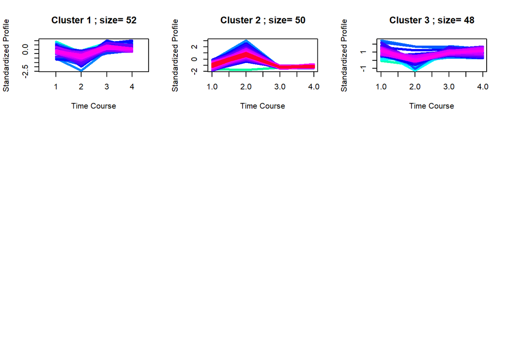

```r
# c mean clustering using 3 cluster
library(e1071)
ir <- scale(ir, center = T, scale = T)
cm1<-cmeans (ir, centers=3, m=2)

# ploting/showing the cmean clustering
fuzzPlot(ir,cm1, mfrow = c(3,3))
```

**#### evaluation table cmean clustering iris data ——————-**

```r
# c mean clustering evaluation with the original lebel

table(iris$Species,cm1$cluster)
```

```
##
##               1  2  3
##   setosa      0 50  0
##   versicolor 39  0 11
##   virginica  13  0 37
```

**#### Clustering results validation iris data clvalid method—————–**

```r
#install.packages("clvalid")
# clValid is a package that containing various cluster validation methods

library(clValid)
intern <- clValid(ir, nClust=2:10, validation="internal", clMethods=c("hierarchical","kmeans", "pam"))
summary(intern)
```

```
##
## Clustering Methods:
##  hierarchical kmeans pam
##
## Cluster sizes:
##  2 3 4 5 6 7 8 9 10
##
## Validation Measures:
##                                  2       3       4       5       6       7       8       9      10
##
## hierarchical Connectivity   0.9762  5.5964  7.5492 18.0508 24.7306 36.0171 41.9028 45.0663 51.1187
##              Dunn           0.2674  0.1874  0.2060  0.0700  0.0762  0.0977  0.1016  0.1016  0.0990
##              Silhouette     0.5818  0.4803  0.4067  0.3746  0.3248  0.3296  0.3293  0.3207  0.3231
## kmeans       Connectivity   0.9762 23.8151 25.9044 40.3060 40.1385 45.5210 52.6940 56.4988 71.5718
##              Dunn           0.2674  0.0265  0.0700  0.0808  0.0808  0.0942  0.1187  0.1187  0.1257
##              Silhouette     0.5818  0.4599  0.4189  0.3455  0.3441  0.3464  0.3398  0.3507  0.3327
## pam          Connectivity   0.9762 23.0726 31.8067 35.7964 44.5413 50.3516 61.6202 63.7964 67.3679
##              Dunn           0.2674  0.0571  0.0566  0.0642  0.0361  0.0430  0.0430  0.0477  0.0560
##              Silhouette     0.5818  0.4566  0.4091  0.3574  0.3400  0.3263  0.3321  0.3310  0.3508
##
## Optimal Scores:
##
##              Score  Method       Clusters
## Connectivity 0.9762 hierarchical 2
## Dunn         0.2674 hierarchical 2
## Silhouette   0.5818 hierarchical 2
```

```r
optimalScores(intern)
```

```
##                  Score       Method Clusters
## Connectivity 0.9761905 hierarchical        2
## Dunn         0.2674261 hierarchical        2
## Silhouette   0.5817500 hierarchical        2
```

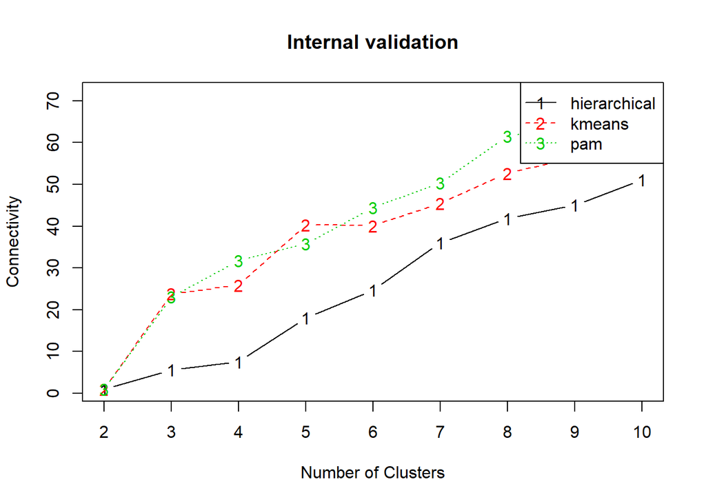

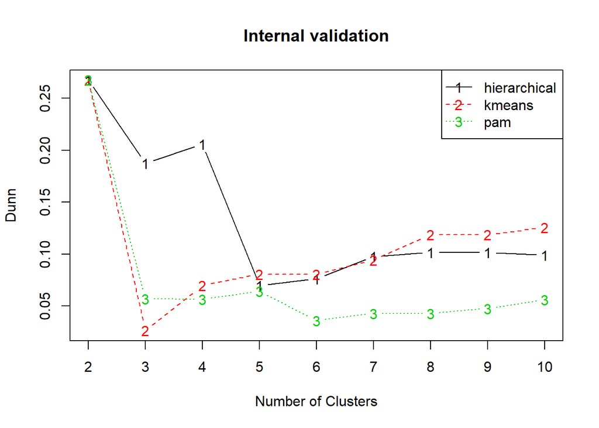

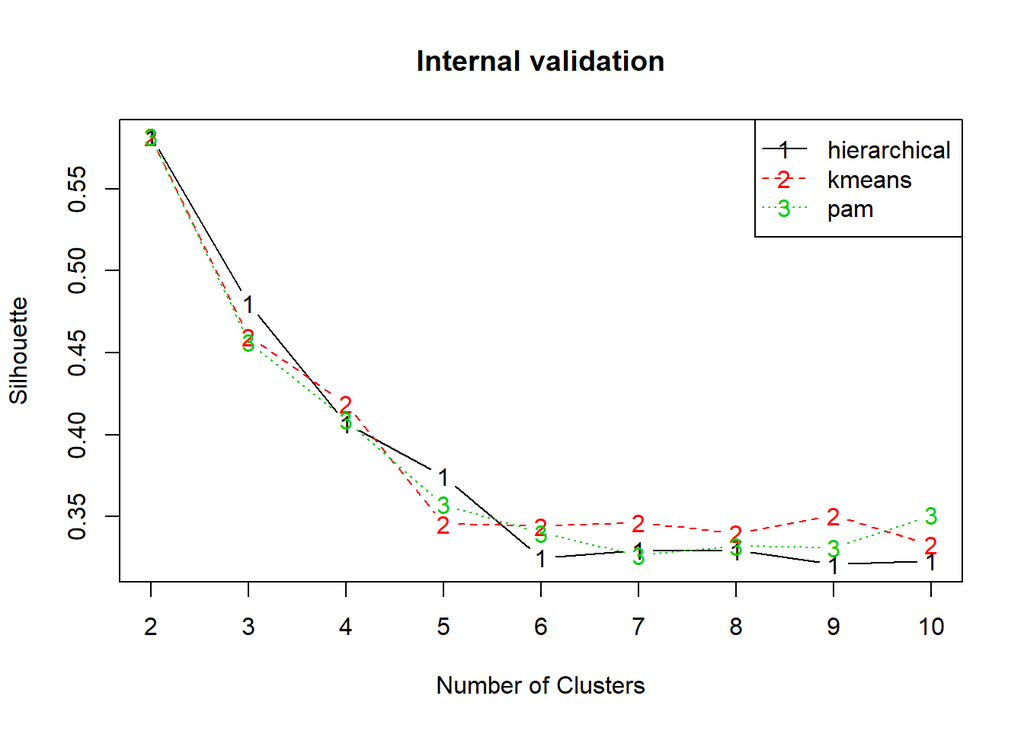

```r
# set up plots
plot(intern)
```

## stability based metrics

**The stability measures evaluate the stability of a clustering result by comparing it with the clusters obtained by removing one column at a time. These measures include the average proportion of non-overlap (APN), the average distance (AD), the average distance between means (ADM), and the figure of merit (FOM). The APN, AD, and ADM are all based on the cross-classification table of the original clustering with the clustering based on the removal of one column. The APN measures the average proportion of observations not placed in the same cluster under both cases, while the AD measures the average distance between observations placed in the same cluster under both cases and the ADM measures the average distance between cluster centers for observations placed in the same cluster under both cases. The FOM measures the average intra-cluster variance of the deleted column, where the clustering is based on the remaining (undeleted) columns. In all cases the average is taken over all the deleted columns, and all measures should be minimized.**

**## validating cluster iris data stability method**

```r
par(mfrow=c(2,2))
stab <- clValid(ir[,-5], nClust=2:10, validation="stability", clMethods=c("hierarchical", "kmeans", "pam"))
optimalScores(stab)
```

```
##           Score       Method Clusters
## APN 0.003266667 hierarchical        2
## AD  0.862098039          pam       10
## ADM 0.016087089 hierarchical        2
## FOM 0.439894698          pam       10
```

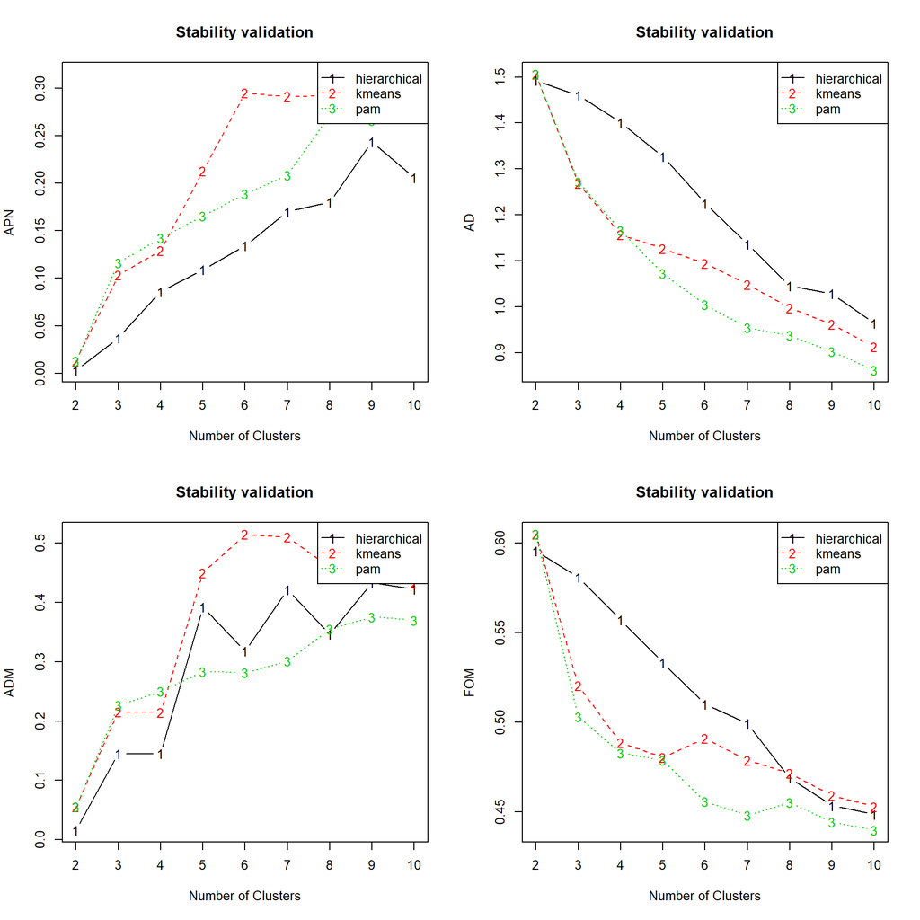

```r
plot(stab)
```

**#########################################################################################**

# hc cluster(iris)

**# hierarchical clustering (iris data)**

**In contrast to the K-means clustering in which we need to explicitly provide how many clusters are we expecting from the data, we do not need to provide such a thing here.**

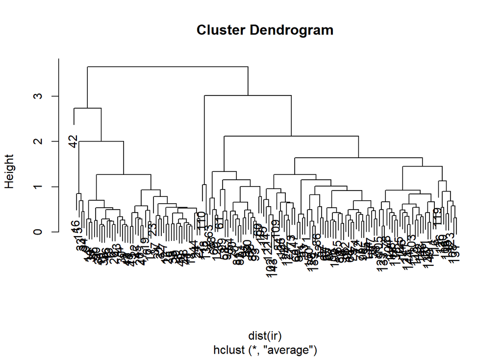

```r
# here also we gonna use our ir data set

hc_avarage=hclust(dist(ir),method="average")
hc_single=hclust(dist(ir),method="single")
hc_complete=hclust(dist(ir),method="complete")
plot(hc_avarage)
```

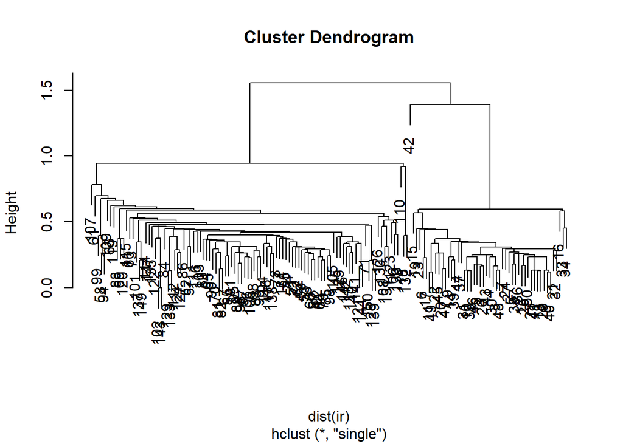

```r
plot(hc_single)
```

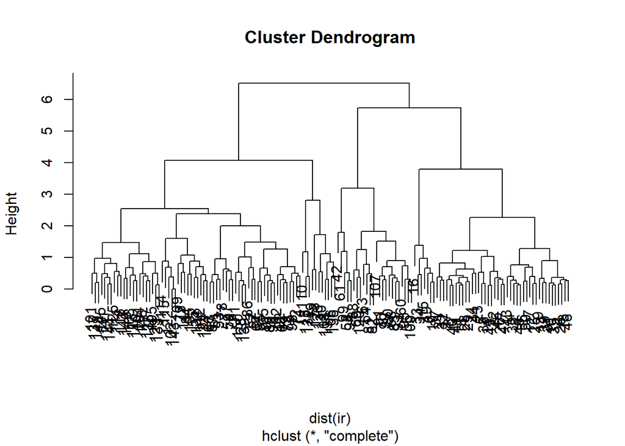

```r
plot(hc_complete)
```

```r
hc_complete
```

```
##
## Call:
## hclust(d = dist(ir), method = "complete")
##
## Cluster method   : complete
## Distance         : euclidean
## Number of objects: 150
```

```r
hc_avarage
```

```
##
## Call:
## hclust(d = dist(ir), method = "average")
##
## Cluster method   : average
## Distance         : euclidean
## Number of objects: 150
```

```r
hc_single
```

```
##
## Call:
## hclust(d = dist(ir), method = "single")
##
## Cluster method   : single
## Distance         : euclidean
## Number of objects: 150
```

**## Tree cutting in Heirarical clustering (iris data)**

```r
# cutting the tree into 3 cluster
cut<-cutree(hc_complete,3)

# show the cut
cut
```

```
##   [1] 1 1 1 1 1 1 1 1 1 1 1 1 1 1 1 1 1 1 1 1 1 1 1 1 1 1 1 1 1 1 1 1 1 1 1
##  [36] 1 1 1 1 1 1 2 1 1 1 1 1 1 1 1 3 3 3 2 3 2 3 2 3 2 2 3 2 3 3 3 3 2 2 2
##  [71] 3 3 3 3 3 3 3 3 3 2 2 2 2 3 3 3 3 2 3 2 2 3 2 2 2 3 3 3 2 2 3 3 3 3 3
## [106] 3 2 3 3 3 3 3 3 3 3 3 3 3 3 2 3 3 3 3 3 3 3 3 3 3 3 3 3 3 3 3 3 3 3 3
## [141] 3 3 3 3 3 3 3 3 3 3
```

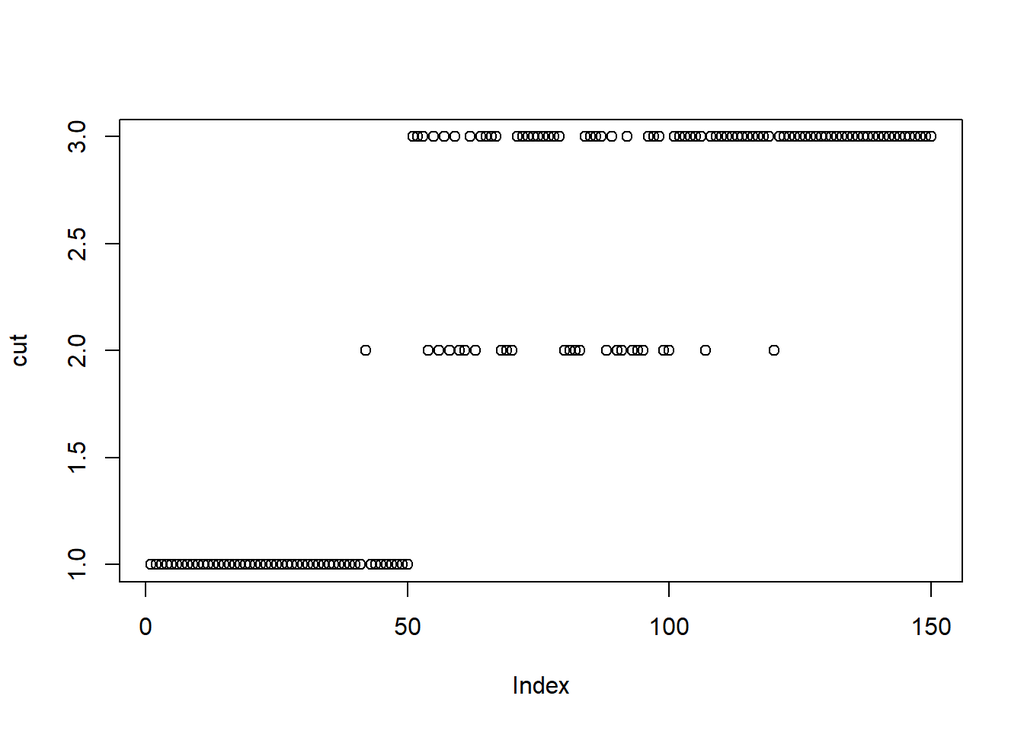

```r
# plot the cut
plot(cut)
```

**## cross validation in the dandogram as we have some lebel here in (iris) data**

```r
# cus is the dendogram with 3 tree comparing with original
table(cut, iris$Species)
```

```
##
## cut setosa versicolor virginica
##   1     49          0         0
##   2      1         21         2
##   3      0         29        48
```

**#########################################################################################**

# hc cluster(mtcar)

```r
#mtcars<-mtcars mtcar data set
# distance matrics
head(mtcars)
```

```
##                    mpg cyl disp  hp drat    wt  qsec vs am gear carb
## Mazda RX4         21.0   6  160 110 3.90 2.620 16.46  0  1    4    4
## Mazda RX4 Wag     21.0   6  160 110 3.90 2.875 17.02  0  1    4    4
## Datsun 710        22.8   4  108  93 3.85 2.320 18.61  1  1    4    1
## Hornet 4 Drive    21.4   6  258 110 3.08 3.215 19.44  1  0    3    1
## Hornet Sportabout 18.7   8  360 175 3.15 3.440 17.02  0  0    3    2
## Valiant           18.1   6  225 105 2.76 3.460 20.22  1  0    3    1
```

```r
d<-dist(mtcars)
```

```r
# clustering algorithhm in the distance matrics
c<-hclust(d)
# call the  hclustering
c
```

```
##
## Call:
## hclust(d = d)
##
## Cluster method   : complete
## Distance         : euclidean
## Number of objects: 32
```

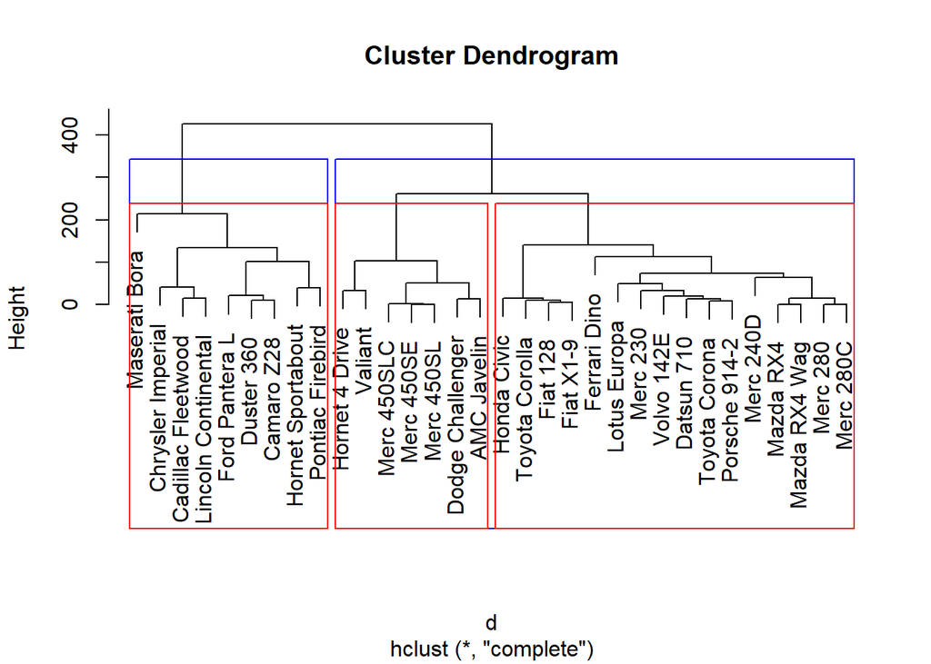

```r
# plot the hclustering
plot(c)

# cut the tree in to 3 cluster
g<-cutree(c, k=3)

# making ractangle in the tree c of 2 cluster
rect.hclust(c, k=2, border="blue")

# making ractangle in the tree c of 3 cluster
rect.hclust(c, k=3, border="red")
```

```r
# plot the g (tree cut)
g
```

```
##           Mazda RX4       Mazda RX4 Wag          Datsun 710
##                   1                   1                   1
##      Hornet 4 Drive   Hornet Sportabout             Valiant
##                   2                   3                   2
##          Duster 360           Merc 240D            Merc 230
##                   3                   1                   1
##            Merc 280           Merc 280C          Merc 450SE
##                   1                   1                   2
##          Merc 450SL         Merc 450SLC  Cadillac Fleetwood
##                   2                   2                   3
## Lincoln Continental   Chrysler Imperial            Fiat 128
##                   3                   3                   1
##         Honda Civic      Toyota Corolla       Toyota Corona
##                   1                   1                   1
##    Dodge Challenger         AMC Javelin          Camaro Z28
##                   2                   2                   3
##    Pontiac Firebird           Fiat X1-9       Porsche 914-2
##                   3                   1                   1
##        Lotus Europa      Ford Pantera L        Ferrari Dino
##                   1                   3                   1
##       Maserati Bora          Volvo 142E
##                   3                   1
```

```r
# cutting the tree into the range of clusters
gr<-cutree(c, k=2:5)
gr
```

```
##                     2 3 4 5
## Mazda RX4           1 1 1 1
## Mazda RX4 Wag       1 1 1 1
## Datsun 710          1 1 1 1
## Hornet 4 Drive      1 2 2 2
## Hornet Sportabout   2 3 3 3
## Valiant             1 2 2 2
## Duster 360          2 3 3 3
## Merc 240D           1 1 1 1
## Merc 230            1 1 1 1
## Merc 280            1 1 1 1
## Merc 280C           1 1 1 1
## Merc 450SE          1 2 2 2
## Merc 450SL          1 2 2 2
## Merc 450SLC         1 2 2 2
## Cadillac Fleetwood  2 3 3 3
## Lincoln Continental 2 3 3 3
## Chrysler Imperial   2 3 3 3
## Fiat 128            1 1 1 4
## Honda Civic         1 1 1 4
## Toyota Corolla      1 1 1 4
## Toyota Corona       1 1 1 1
## Dodge Challenger    1 2 2 2
## AMC Javelin         1 2 2 2
## Camaro Z28          2 3 3 3
## Pontiac Firebird    2 3 3 3
## Fiat X1-9           1 1 1 4
## Porsche 914-2       1 1 1 1
## Lotus Europa        1 1 1 1
## Ford Pantera L      2 3 3 3
## Ferrari Dino        1 1 1 1
## Maserati Bora       2 3 4 5
## Volvo 142E          1 1 1 1
```

**#########################################################################################**

# clustering(wine data)

**# Some more clustering using wine data set:**

**Usually when dealing with an unsupervised learning problem, its difficult to get a good measure of how well the model performed. For this project, we will use data from the UCI archive based off of red and white wines (this is a very commonly used data set in ML)**

```r
# read the table from UCI

redwine = read.table("http://archive.ics.uci.edu/ml/machine-learning-databases/wine-quality/winequality-red.csv", header= TRUE, sep = ";", dec = ".")
whitewine=read.table("http://archive.ics.uci.edu/ml/machine-learning-databases/wine-quality/winequality-white.csv", header= TRUE, sep = ";", dec = ".")
```

```r
# ADDING EXTRA LEBEL IN THE END OF THE FILE WHICH WILL USE USE FOR FUTURE EVALUATION


redwine[,13]<-'red'
whitewine[,13]<-'white'
```

```r
#Combine both data file into a single data frame called wine.

wine <- rbind(redwine,whitewine)

#str(wine)
```

**# k mean clustering (wine data) ———————————–**

```r
# APPLYING THE K MEAN CLUSTERING ALGORITHM WITHOUT INFORMING THE ALGORITHM THE NAME OF THE LABEL
# WE USING TWO CLUSTER HERE

wine.cluster <- kmeans(wine[1:12],2)
#wine.cluster
```

```r
wine.cluster$centers
```

```
##   fixed.acidity volatile.acidity citric.acid residual.sugar chlorides
## 1      6.904698        0.2871364   0.3398094       7.259286 0.0486092
## 2      7.619044        0.4079451   0.2911080       3.082690 0.0656846
##   free.sulfur.dioxide total.sulfur.dioxide   density       pH sulphates
## 1            39.82503            155.90101 0.9947956 3.190308 0.5000354
## 2            18.43735             63.54832 0.9945680 3.255147 0.5718655
##    alcohol  quality
## 1 10.25832 5.825436
## 2 10.79529 5.809204
```

**## cluster Evaluation (k mean wine data)———————————-**

```r
# now lets see how the algorithm is working while known lebel was comparing
# red wine classified well

table(wine$V13,wine.cluster$cluster)
```

```
##
##            1    2
##   red     84 1515
##   white 3588 1310
```

**## Fuzzy cmean clustering in wine data——————————-**

```r
library(e1071)
tempwine<-wine[,1:11]
fc <- cmeans(wine[,1:11], centers=3)
```

**## Visualise the clustering results using ClueR package function “fuzzPlot” as follows:**

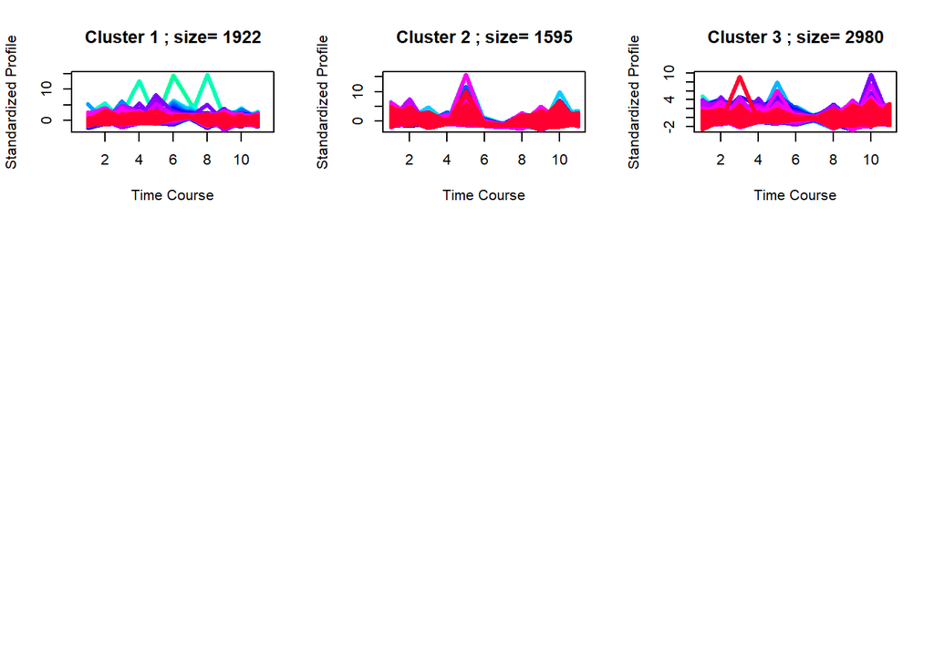

```r
tempwine <- scale(tempwine[,1:11], center = T, scale = T)
fuzzPlot(tempwine, fc, mfrow = c(3, 3))
```

**## Clustering results validation(wine data in stability method)**

```r
# making the last colum of the table as null to make all colum as numeric
#9% data in random since the data size is so big for this iteration, using dplyr only selected this random
# data for clustering validation
library(dplyr)
wine$v13<-NULL
wine$quality<-NULL
tempwine<-sample_frac(wine[,1:11], size = 0.09)
str(tempwine)
```

```
## 'data.frame':    585 obs. of  11 variables:
##  $ fixed.acidity       : num  6.3 6.4 5.6 6.8 9.2 7 9.4 9 7.5 6.5 ...
##  $ volatile.acidity    : num  0.38 0.2 0.33 0.23 0.23 0.13 0.4 0.6 0.59 0.25 ...
##  $ citric.acid         : num  0.17 0.22 0.28 0.48 0.3 0.37 0.31 0.29 0.22 0.27 ...
##  $ residual.sugar      : num  8.8 7.4 1.2 1.5 1.1 ...
##  $ chlorides           : num  0.08 0.032 0.031 0.036 0.031 0.042 0.09 0.069 0.082 0.064 ...
##  $ free.sulfur.dioxide : num  50 53 33 35 40 36 13 32 43 29 ...
##  $ total.sulfur.dioxide: num  212 172 97 165 99 105 62 73 60 140 ...
##  $ density             : num  0.998 0.994 0.991 0.992 0.993 ...
##  $ pH                  : num  3.47 3.24 3.49 3.18 2.94 3.05 3.07 3.34 3.1 3.2 ...
##  $ sulphates           : num  0.66 0.58 0.58 0.45 0.3 0.55 0.63 0.57 0.42 0.49 ...
##  $ alcohol             : num  9.4 11 10.9 11.3 10.4 10.7 10.5 10 9.2 10.1 ...
```

```r
library(clValid)
#par(mfrow=c(2,2))
stab <- clValid(tempwine[,-5], nClust=2:10, validation=c("stability", "internal"), clMethods=c("hierarchical", "kmeans", "pam"))
optimalScores(stab)
```

```
##                    Score       Method Clusters
## APN           0.01865878 hierarchical        2
## AD           19.24367431          pam       10
## ADM           3.31955847          pam        3
## FOM           5.32332369       kmeans        9
## Connectivity  6.39007937 hierarchical        2
## Dunn          0.05033741 hierarchical       10
## Silhouette    0.52271967          pam        3
```

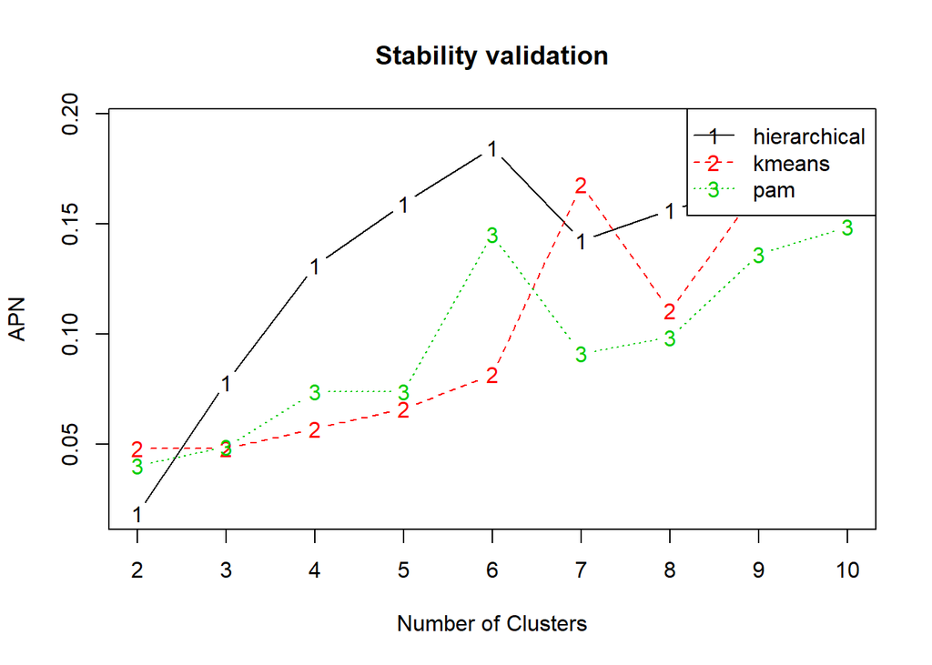

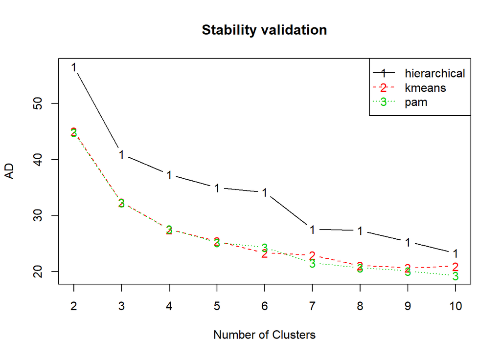

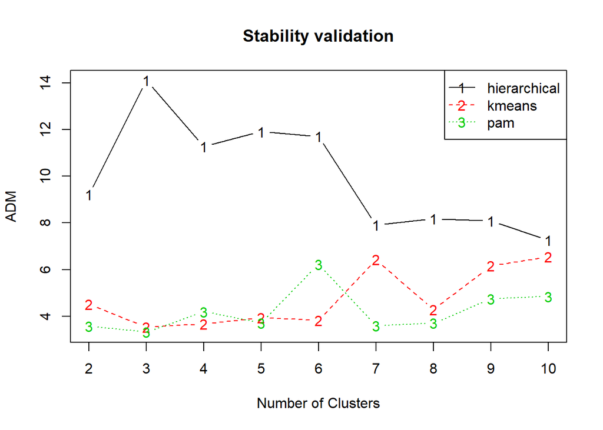

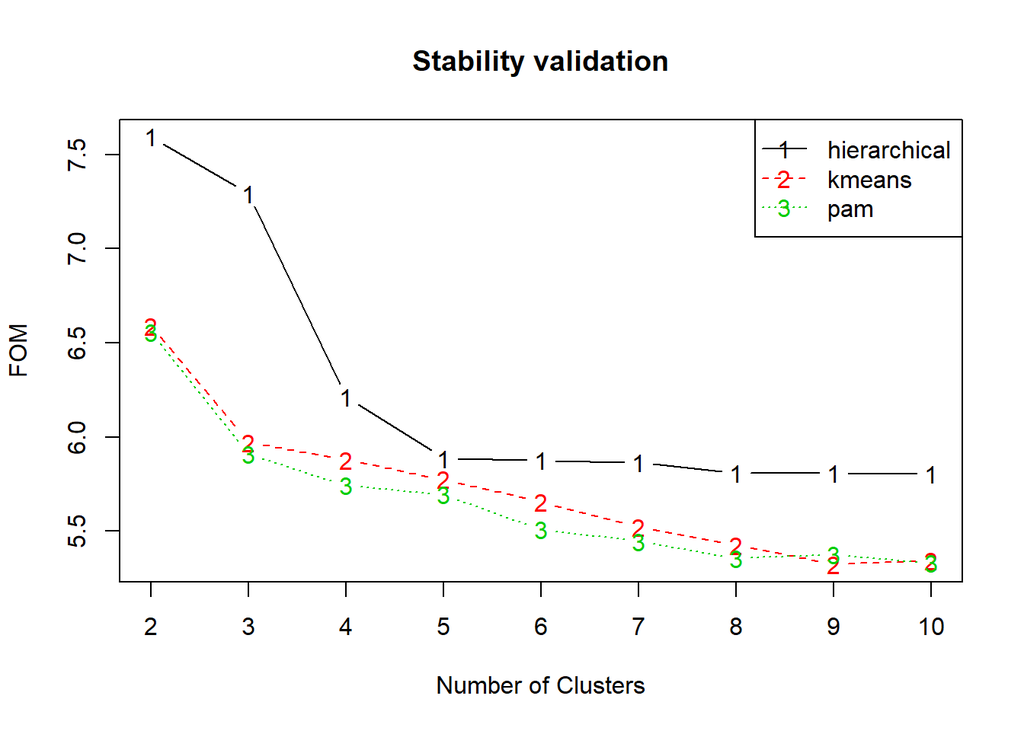

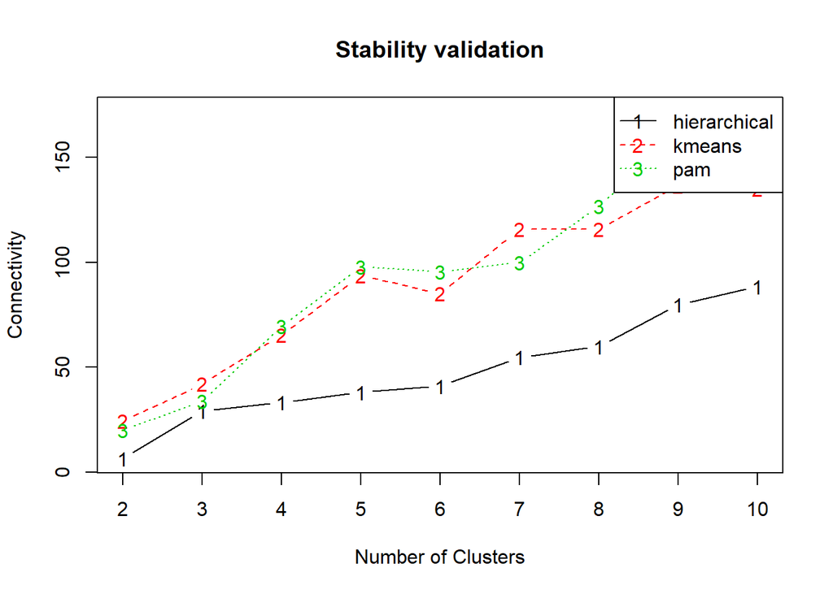

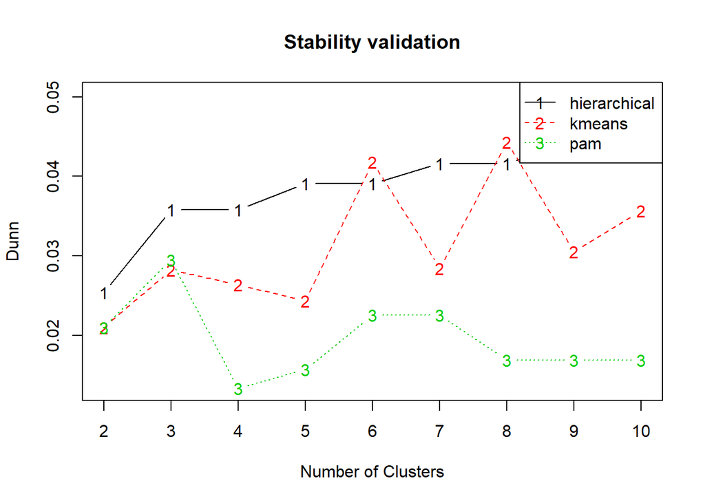

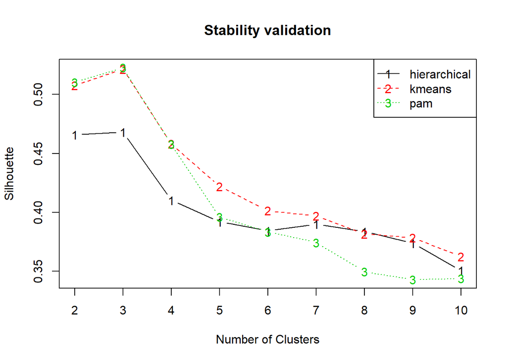

```r
plot(stab)
```

```r
# Calculate Dunn's index: dunn_km. Print it.
# dun index vs number of k in the wine data
library(clValid)

k.vec <- c()
dunn.vec <- c();


for (k in 2:12) {

    wine_km <- kmeans(wine[,1:11], k, nstart = 20)

    dunn_km = dunn(clusters = wine_km$cluster, Data=wine)
    dunn.vec <-append(dunn.vec, dunn_km)
    k.vec <- append(k.vec, k)
}
```

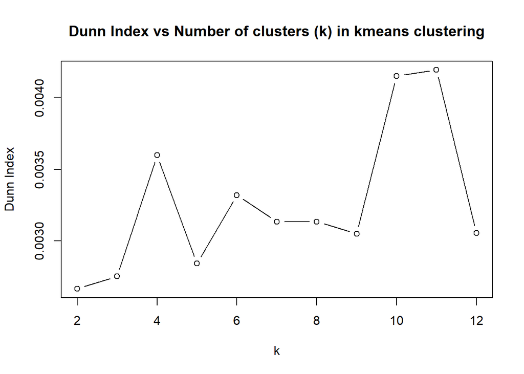

```r
plot(k.vec, dunn.vec, type="b", xlab="k", ylab="Dunn Index", main="Dunn Index vs Number of clusters (k) in kmeans clustering")
```